# Weather Predictor Model -- Using Amazon Forecast to Predict Weather in Basel, Switzerland.

### Authors: Audrey Bu, Alina Chen, Indy Gu, Alvin Jiao, Yiran Liu

# Initial Motivation

Alvin Jiao: I embarked on a journey to Basel, Switzerland last year to experience its renowned art scene and history. However, this trip turned out to be unexpected. One day, I planned to visit the Fondation Beyeler, a famous art museum in Basel. The weather forecast promised a day of sunshine and clear skies. However, by noon, the weather had taken an unforeseen turn which a sudden downpour and falsh caught me and many other tourists have to change their plans. This abrupt change in weather led to canceled plans and a day spent seeking shelter instead of exploring.

This experience sparked a project idea within our team. Recognizing the impact of unreliable weather forecasts on travel experiences, we aimed to create a solution using advanced forecasting models. Leveraging Amazon Forecast's time-series capabilities, we focused on Basel, analyzing historical data to predict rare weather events accurately. Our goal i to create a more precise forecasting model, poised to revolutionize travel planning, providing travelers like Alvin with better preparedness and flexibility for a seamless travel experience. This project not only bridged the gap between research and application but also offered a practical solution to enhance travel planning worldwide.

# Data Collection

Upon Alvin's idea, we collected data from the website Meteoblue (https://www.meteoblue.com/en/weather/archive/export). The dataset contains hourly observations of three weather factors: Temperature, Precipitation, and Wind Gust from the year 1960 to 2023. In order to use the data for machine learning, we split it into the training set (80%) and test set (20%) in time series order. In other words, we want to train our model using historical data points and evaluate it using more current ones. We have uploaded all the datasets to a S3 bucket on AWS.

Before doing the machine learning with Amazon Forecast, we want to analyze the dataset a bit to get a general understanding of it.

# Data loading, preprocessing, and train-test spliting

First, we need to load necessary libraries and the data set. We use the pandas and numpy library to load the data set and perform basic operations, seaborn and matplotlib for plotting. The data set is stored in the variable df.

```python
import pandas as pd
import numpy as np
import matplotlib.pyplot as plt
import seaborn as sns
```

Next, we load the data using pd.read_csv() function. The data set is stored in the variable df. Please modify the file path to the data set accordingly if you are using a different directory structure. We then use df.head() to display the first 5 rows of the data set.

```python
df = pd.read_csv('/Users/jiaaayiccch/Desktop/350 project/Basel.csv')
df.head()
```

|  | timestamp | Basel Temperature [2 m elevation corrected] | Basel Precipitation Total | Basel Wind Gust |
| --- | --- | --- | --- | --- |
| 0 | 19600101T0000 | 37.994442 | 0.0 | 18.359999 |
| 1 | 19600101T0100 | 38.066440 | 0.0 | 20.160000 |
| 2 | 19600101T0200 | 38.120440 | 0.0 | 21.599998 |
| 3 | 19600101T0300 | 39.776440 | 0.0 | 22.319998 |
| 4 | 19600101T0400 | 40.172440 | 0.0 | 22.319998 |

After loading the data, we first add a new column called ID with unique values. Then, we convert the timestamp column to datetime format that's suitable for S3 and Amazon forecast.

```python
# Add a new column 'ID' with unique values
df['item_id'] = 1

# Convert the 'timestamp' column to a datetime object
df['timestamp'] = pd.to_datetime(df['timestamp'], format='%Y%m%dT%H%M%S')

# Format the 'timestamp' column in 'yyyy-mm-dd' format
#df['timestamp'] = df['timestamp'].dt.strftime('%Y-%m-%d')

df['item_id'] = df['item_id'].astype(str)
```

Further, we modify the column names to remove spaces and special characters. We also convert the column names to **lower case**. This is required for Amazon Forecast.

```python
new_column_names = {'Basel Temperature [2 m elevation corrected]': 'target_value',
                    'Basel Precipitation Total': 'precipitation',
                    'Basel Wind Gust': 'wind'}
df = df.rename(columns=new_column_names)
```

Now, it is time to have a view of preprocessed data set. We use the head() function to view the first 5 rows of the data set.

```python
df.head(5)
```

|  | timestamp | target_value | precipitation | wind | item_id |
| --- | --- | --- | --- | --- | --- |
| 0 | 1960-01-01 00:00:00 | 37.994442 | 0.0 | 18.359999 | 1 |
| 1 | 1960-01-01 01:00:00 | 38.066440 | 0.0 | 20.160000 | 1 |
| 2 | 1960-01-01 02:00:00 | 38.120440 | 0.0 | 21.599998 | 1 |
| 3 | 1960-01-01 03:00:00 | 39.776440 | 0.0 | 22.319998 | 1 |
| 4 | 1960-01-01 04:00:00 | 40.172440 | 0.0 | 22.319998 | 1 |

Our investigation focus is on the temperature, so we create a new data frame with only the temperature column. We then plot the temperature data to see the trend.

```python
temperature_df=df[['timestamp','target_value', 'item_id']]
```

Let's look at the temperature_df we have created

```python
temperature_df.head()
```

|  | timestamp | target_value | item_id |
| --- | --- | --- | --- |
| 0 | 1960-01-01 00:00:00 | 37.994442 | 1 |
| 1 | 1960-01-01 01:00:00 | 38.066440 | 1 |
| 2 | 1960-01-01 02:00:00 | 38.120440 | 1 |
| 3 | 1960-01-01 03:00:00 | 39.776440 | 1 |
| 4 | 1960-01-01 04:00:00 | 40.172440 | 1 |

Finally, we will do the train-test split. We will use the first 80% of the data for training and the remaining 20% for testing. Then, we export the train and test data to csv files. We will use these files for training and testing the Amazon Forecast model.

```python
split_index = int(0.8 * len(df))
```

This index is for extracting the first 80% of the data for training.

```python
# Split the DataFrame
train_data = temperature_df.iloc[:split_index]
test_data = temperature_df.iloc[split_index:]

# Optional: Reset index for both DataFrames
train_data = train_data.reset_index(drop=True)
test_data = test_data.reset_index(drop=True)
```

Then, using the index, we get the training and testing data.

```python
# Save the training data to a new CSV file
train_data.to_csv('train_tempeature.csv', index=False)

# Save the test data to a new CSV file
test_data.to_csv('groundtruth_temperature.csv', index=False)
```

we export the train and test data to csv files. We will use these files for training and testing the Amazon Forecast model.

We have finished all steps for data loading, preprocessing, and train-test spliting. Now, we are ready to move on to the next step!

# Data Analysis

## 1. Basic statistics of the data set:

Let's look at the basic statistics of the data set to get a sense of what we are working with.

We first use info() function to get the basic information of the data set.

```python
temperature_df.info()
```

```
<class 'pandas.core.frame.DataFrame'>
RangeIndex: 559489 entries, 0 to 559488
Data columns (total 3 columns):
 #   Column        Non-Null Count   Dtype
---  ------        --------------   -----
 0   timestamp     559489 non-null  datetime64[ns]
 1   target_value  559489 non-null  float64
 2   item_id       559489 non-null  object
dtypes: datetime64[ns](1), float64(1), object(1)
memory usage: 12.8+ MB
```

We use the describe() function to get the basic statistics of the data set. The describe() function returns the count, mean, standard deviation, minimum and maximum values, and the quantiles of the data set. The describe() function only returns the statistics of the numerical columns.

```python
# Basic Statistics
print(temperature_df.describe())
```

```
        target_value
count  559489.000000
mean       51.191709
std        14.537318
min        -9.345558
25%        40.298440
50%        50.900440
75%        61.502440
max       101.426445
```

These statistics collectively provide a comprehensive overview of the temperature data. They indicate a wide range of temperatures with moderate variability, a mean temperature slightly above the median, and suggest the presence of both low and high extremes in the dataset.

Now, let's check for the missing values. We use the isnull() function to check for the missing values. The isnull() function returns True if the value is missing and False if the value is not missing. We use the sum() function to count the number of missing values in each column. The sum() function returns the sum of all the values in each column. Since the isnull() function returns True for 1 and False for 0, the sum() function returns the number of missing values in each column.

```python
print(temperature_df.isnull().sum())
```

```
timestamp       0
target_value    0
item_id         0
dtype: int64
```

For the temperature we are investigating, we have 0 missing values.

## 2. Data Visualization:

Let's first look at the temperature trends over time. We use plt.figure() to initialize the figure and plt.plot() to plot the temperature against the date. We use plt.xlabel() and plt.ylabel() to set the labels for the x-axis and y-axis respectively. We use plt.title() to set the title of the plot. We use plt.show() to display the plot.

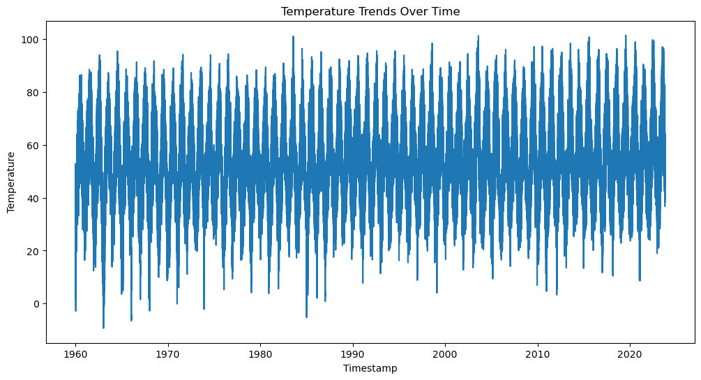

```python
plt.figure(figsize=(12, 6))
plt.plot(temperature_df['timestamp'], temperature_df['target_value'])
plt.title('Temperature Trends Over Time')
plt.xlabel('Timestamp')
plt.ylabel('Temperature')
plt.show()
```

The temperature plot presents a comprehensive view of hourly temperature data from the 1960s to the 2020s, characterized by pronounced, regular oscillations indicative of seasonal variations. While the plot shows no apparent long-term trend suggesting significant global temperature changes, it maintains a consistent range between the extremes, indicating stable temperature patterns over the decades. The plot's density reflects the hourly data collection frequency, which might obscure finer trends that could be unveiled through data aggregation into larger time units. Occasional sharp spikes suggest potential outliers or rare extreme weather events. Further analysis with statistical tools could clarify underlying trends and isolate seasonal effects from long-term changes.

Next, we will draw a histogram to visualize the distribution of the temperature data. We use plt.figure() to initialize the figure and plt.hist() to plot the histogram of the temperature data. We use plt.xlabel() and plt.ylabel() to set the labels for the x-axis and y-axis respectively. We use plt.title() to set the title of the plot. We use plt.show() to display the plot.

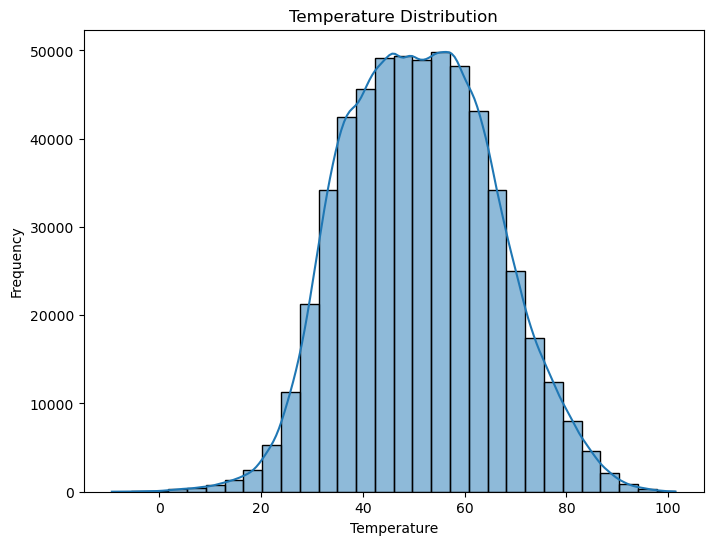

```python
plt.figure(figsize=(8, 6))
sns.histplot(temperature_df['target_value'], bins=30, kde=True)
plt.title('Temperature Distribution')
plt.xlabel('Temperature')
plt.ylabel('Frequency')
plt.show()
```

The histogram provided represents the frequency distribution of temperature data. It's shaped like a bell curve, which closely resembles a normal distribution, suggesting that most temperature readings cluster around the mean, with fewer readings observed as you move towards the extremes. The peak of the distribution appears to be around 50 units, which could be interpreted as the most common temperature range in the dataset. The spread of the data, from near 0 to 100, indicates a wide range of temperatures but with most occurrences around the central value, thus reflecting a typical distribution you might expect from a large set of temperature data. This kind of distribution is beneficial for statistical analysis and predictive modeling since many statistical techniques assume normality. The tails of the distribution taper off, showing that extremely low and high temperatures are relatively rare. This visualization is a key tool for understanding the overall behavior of temperature variation within the dataset.

In the next step of our analysis, we aim to understand how temperature distributions vary with the seasons. To do this, we need to ensure our dataset is indexed by time, allowing us to extract date-related attributes such as the year and month. First, we will convert our date and time information into a DatetimeIndex to facilitate time-based indexing. Once our DataFrame is indexed by datetime, we will extract the 'year' and 'month' from the index, enabling us to categorize our data by these time units. Subsequently, we will map each month to its corresponding season—winter, spring, summer, or autumn. With these new columns in place, we can employ both violin and box plots to visually compare the temperature distributions across different seasons. Violin plots will provide us with a rich depiction of the distribution, showing us both the median and the spread of the data, while box plots will give a summary of the distribution's quartiles and outliers. This visualization will be crucial for interpreting the seasonal effects on temperature.

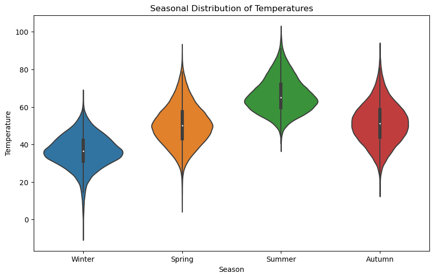

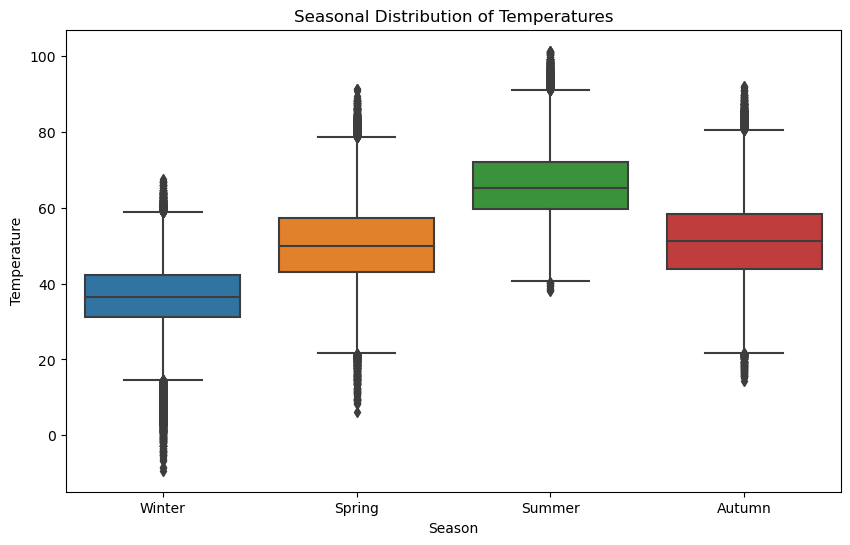

```python
temperature_df['timestamp'] = pd.to_datetime(temperature_df['timestamp']).copy()

temperature_df.set_index('timestamp', inplace=True)

temperature_df['year'] = temperature_df.index.year
temperature_df['month'] = temperature_df.index.month
temperature_df['year'] = temperature_df.index.year
temperature_df['month'] = temperature_df.index.month

seasons = {
    12: 'Winter', 1: 'Winter', 2: 'Winter',
    3: 'Spring', 4: 'Spring', 5: 'Spring',
    6: 'Summer', 7: 'Summer', 8: 'Summer',
    9: 'Autumn', 10: 'Autumn', 11: 'Autumn'
}


temperature_df['season'] = temperature_df['month'].map(seasons)


plt.figure(figsize=(10, 6))
sns.violinplot(x='season', y='target_value', data=temperature_df)
plt.title('Seasonal Distribution of Temperatures')
plt.xlabel('Season')
plt.ylabel('Temperature')
plt.show()


plt.figure(figsize=(10, 6))
sns.boxplot(x='season', y='target_value', data=temperature_df)
plt.title('Seasonal Distribution of Temperatures')
plt.xlabel('Season')
plt.ylabel('Temperature')
plt.show()
```

## 3. Correlation Analysis:

Finally, we will perform some auto-correlation analysis and partial auto-correlation analysis to determine the correlation between the temperature values at different time intervals. We use the plot_acf() function to plot the auto-correlation graph and the plot_pacf() function to plot the partial auto-correlation graph. We use plt.show() to display the plot. The auto-correlation graph shows the correlation between the temperature values at different time intervals. The partial auto-correlation graph shows the correlation between the temperature values at different time intervals excluding the correlation due to the intermediate time intervals.

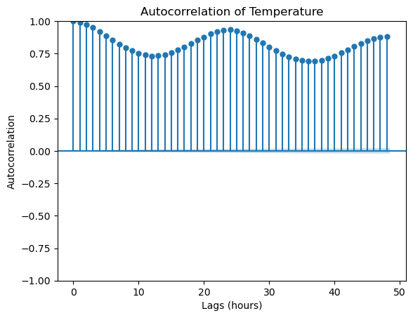

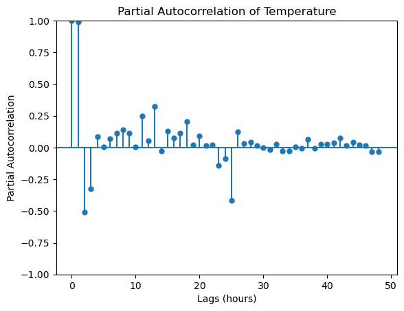

```python
from statsmodels.graphics.tsaplots import plot_acf, plot_pacf

temperature_df.sort_index(inplace=True)


plot_acf(temperature_df['target_value'], lags=48)
plt.title('Autocorrelation of Temperature')
plt.xlabel('Lags (hours)')
plt.ylabel('Autocorrelation')
plt.show()

# Perform Partial Autocorrelation Analysis
plot_pacf(temperature_df['target_value'], lags=48)  # 48 lags for 2 days of hourly data
plt.title('Partial Autocorrelation of Temperature')
plt.xlabel('Lags (hours)')
plt.ylabel('Partial Autocorrelation')
plt.show()
```

The autocorrelation plot shows the correlation of the temperature data with itself at various lags, which in this context are hourly time steps. The consistent oscillation with a periodicity of 24 hours (as seen by peaks every 24 lags) suggests a strong daily pattern, likely related to the diurnal cycle of temperatures rising during the day and falling at night. The autocorrelation values are positive and significant for at least the first 24 hours, indicating that past values have a predictive quality for at least one day ahead.

# Machine Learning Architechture

In our machine learning scheme, we decided to focus on the temperature of Basel only due to the HUGE dataset. We feared that if we cut off some observations it will affect the performance of the model.

[figure not shown]

```python
from IPython.display import Image

Image(filename='ArcD.jpg', width=1000)
```

# Machine Learning Results

[Here](https://amazonforecastbasel.s3.amazonaws.com/ML+with+Amazon+Forecast.html) is the link to the walkthrough in html.

### Estimation Errors

For the 24-hour predictor, we got pretty decent estimation errors:

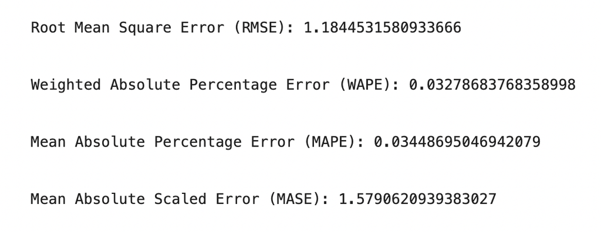

```python
Image(filename='24hr errors.png', width=500)
```

### Plot

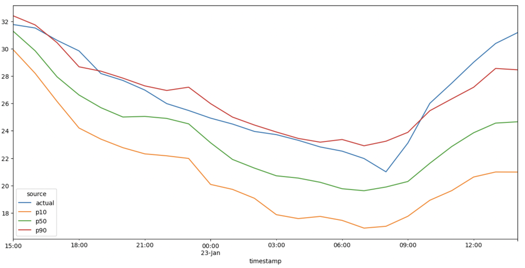

```python
Image(filename='24hr.png', width=1000)
```

From the plot, we can see that the actual temperature falls in between the 90% interval and the 50% percent interval most of the times. In real world scenarios (like for Alvin's future traveling plans), we think that this is decent predictions of the temperature.

# Discussion

While our project using Amazon Forecast has demonstrated commendable performance in predicting weather features, particularly temperature, it's crucial to acknowledge certain limitations both within our project and inherent to the Amazon Forecast platform.

First of all, we only ran Amazon Forecast on Temperature instead of all three factors (other two being Precipitation and Wind Gust). This is because running this amount of data takes huge amount of time and needs additional data processing required by Amazon Forecast. The future step is to examine other weather factors, and given its good performance on Temperature, Amazon Forecast is pretty promising.

Secondly, since we used regional weather data, the model's ability to predict weather of regions with greater variations is unknown and need future investigations.

During our interactions with Amazon Forecast, we found several limitations as well.

Firstly, the platform demands meticulous data preprocessing, involving the handling of missing values and the selection of relevant features, which can be intricate and necessitate domain-specific knowledge.

Additionally, achieving optimal model performance often involves time-consuming hyperparameter tuning; while Amazon Forecast provides automated approaches, manual tuning may be necessary for optimal results.

Lastly, the training of complex models on large datasets can be computationally intensive and resource-demanding, potentially posing challenges for users with limited computational capabilities.

These limitations underscore the importance of a nuanced understanding of Amazon Forecast's capabilities and considerations for users in different contexts.

# Github Link

[Here](https://github.com/AlinaChenjiayi/Group2ProjectFA23/blob/main/S3%20bucket%20guide%20pics/Step1.6.png) is the link to our Github repository if you want to replicate our project.

This paragraph will explain how to implement this notebook to predict the temperature using AWS Forecast API. First, user should download 'util' in our GitHub dataset folder to be used as necessary library for this prediction task (can be also downloaded from AWS GitHub https://github.com/aws-samples/amazon-forecast-samples/tree/bb5c3914d2864d4fe2970f48cbd5a1d0a7b5244f/notebooks/common ). Before running this notebook, users should also update 'role_arn' to their own AWS Arn. 'predictor_arn' and 'forecast_arn' can be updated along the training process, by extracting them from the user's AWS Forecast.